# AllLife Bank Customer Segmentation

### Hierarchical Clustering

```python
# list of distance metrics

distance_metrics = ["euclidean", "chebyshev", "mahalanobis", "cityblock"]

# list of linkage methods

linkage_methods = ["single", "complete", "average", "weighted"]

high_cophenet_corr = 0
high_dm_lm = [0, 0]

# Nested for loop, running a model with all combinations of distance metrics
# and linkage methods

for dm in distance_metrics:
    for lm in linkage_methods:
        Z = linkage(dfScaled, metric=dm, method=lm)
        c, coph_dists = cophenet(Z, pdist(dfScaled))
        print(
            "Cophenetic correlation for {} distance and {} linkage is {}.".format(
                dm.capitalize(), lm, c
            )
        )
        if high_cophenet_corr < c:
            high_cophenet_corr = c
            high_dm_lm[0] = dm
            high_dm_lm[1] = lm
```

```
Cophenetic correlation for Euclidean distance and single linkage is 0.7391220243806552.
Cophenetic correlation for Euclidean distance and complete linkage is 0.8599730607972423.
Cophenetic correlation for Euclidean distance and average linkage is 0.8977080867389372.
Cophenetic correlation for Euclidean distance and weighted linkage is 0.8861746814895477.
Cophenetic correlation for Chebyshev distance and single linkage is 0.7382354769296767.
Cophenetic correlation for Chebyshev distance and complete linkage is 0.8533474836336782.
Cophenetic correlation for Chebyshev distance and average linkage is 0.8974159511838106.
Cophenetic correlation for Chebyshev distance and weighted linkage is 0.8913624010768603.
Cophenetic correlation for Mahalanobis distance and single linkage is 0.7058064784553608.
Cophenetic correlation for Mahalanobis distance and complete linkage is 0.6663534463875372.
Cophenetic correlation for Mahalanobis distance and average linkage is 0.8326994115042138.
Cophenetic correlation for Mahalanobis distance and weighted linkage is 0.7805990615142515.
Cophenetic correlation for Cityblock distance and single linkage is 0.7252379350252723.
Cophenetic correlation for Cityblock distance and complete linkage is 0.8731477899179829.
Cophenetic correlation for Cityblock distance and average linkage is 0.896329431104133.
Cophenetic correlation for Cityblock distance and weighted linkage is 0.8825520731498188.
```

```python
# Printing the combination with the highest cophenetic correlation
print(
    "Highest cophenetic correlation is {}, which is obtained with {} distance and {} linkage.".format(
        high_cophenet_corr, high_dm_lm[0].capitalize(), high_dm_lm[1]
    )
)
```

```
Highest cophenetic correlation is 0.8977080867389372, which is obtained with Euclidean distance and average linkage.
```

```python
# Next, I will try all linkage methods, combined with Euclidean distance

linkage_methods = ["single", "complete", "average", "centroid", "ward", "weighted"]

high_cophenet_corr = 0
high_dm_lm = [0, 0]

for lm in linkage_methods:
    Z = linkage(dfScaled, metric="euclidean", method=lm)
    c, coph_dists = cophenet(Z, pdist(dfScaled))
    print("Cophenetic correlation for {} linkage is {}.".format(lm, c))
    if high_cophenet_corr < c:
        high_cophenet_corr = c
        high_dm_lm[0] = "euclidean"
        high_dm_lm[1] = lm
```

```
Cophenetic correlation for single linkage is 0.7391220243806552.
Cophenetic correlation for complete linkage is 0.8599730607972423.
Cophenetic correlation for average linkage is 0.8977080867389372.
Cophenetic correlation for centroid linkage is 0.8939385846326323.
Cophenetic correlation for ward linkage is 0.7415156284827493.
Cophenetic correlation for weighted linkage is 0.8861746814895477.
```

#### Observations

- I still get the highest cophenetic correlation with average linkage
- This means that, for average linkage, the dendogramic distance between groups is highly correlated with the Euclidean distance; therefore, it is the most true to the original data
- I will view dendograms for the top 3 linkage methods
- These are average, centroid, and weighted
- The others are low enough that it is a safe bet that they aren't the best, and running only 3 dendograms will cut down on computational time

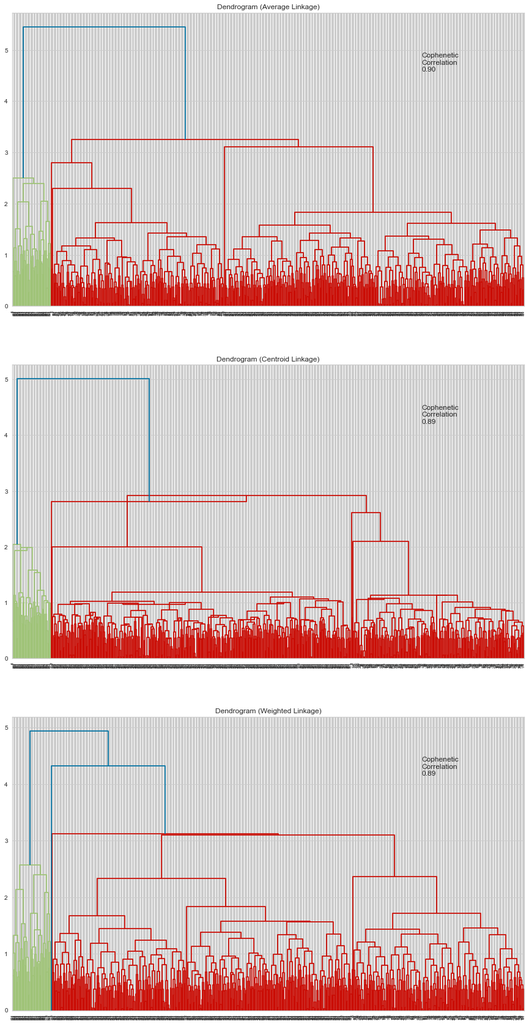

```python
# List of linkage methods

linkage_methods = ["average", "centroid", "weighted"]

# Lists to save results of cophenetic correlation calculation

compare_cols = ["Linkage", "Cophenetic Coefficient"]

# To create a subplot image

fig, axs = plt.subplots(len(linkage_methods), 1, figsize=(15, 30))

# We will enumerate through the list of linkage methods above
# For each linkage method, we will plot the dendrogram and calculate the cophenetic correlation

for i, method in enumerate(linkage_methods):
    Z = linkage(dfScaled, metric="euclidean", method=method)

    dendrogram(Z, ax=axs[i])
    axs[i].set_title(f"Dendrogram ({method.capitalize()} Linkage)")

    coph_corr, coph_dist = cophenet(Z, pdist(dfScaled))
    axs[i].annotate(
        f"Cophenetic\nCorrelation\n{coph_corr:0.2f}",
        (0.80, 0.80),
        xycoords="axes fraction",
    )
```

#### Observations

- The dendograms for Weighted and Centroid linkage look very similar, but the Average looks slightly different
- The Average looks better - we appear to have more homogenous group sizes at the second split into 3 clusters
- Given this, along with the fact that Average has the highest cophonetic correlation, I will choose Euclidean Distance paired with Average Linkage.
- Based on the dendogram, I would predict that we would get the best silhouette scores from 3-5 clusters
- I will calculate silhouette scores on the range from 2 - 9 clusters.

```
For n_clusters = 2, silhouette score is 0.5703183487340725
For n_clusters = 3, silhouette score is 0.5159224326510256
For n_clusters = 4, silhouette score is 0.4749514359579958
For n_clusters = 5, silhouette score is 0.4403975302479004
For n_clusters = 6, silhouette score is 0.4153547954832061
For n_clusters = 7, silhouette score is 0.4183775674672634
For n_clusters = 8, silhouette score is 0.3430671035828747
For n_clusters = 9, silhouette score is 0.3415486932891558
```

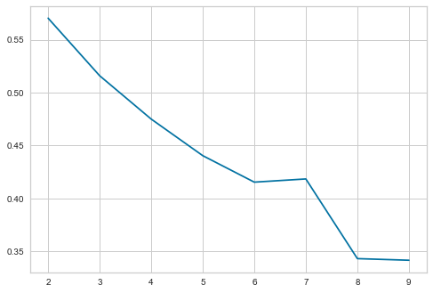

```python
sil_score2 = []
cluster_list2 = list(range(2, 10))
for n_clusters in cluster_list2:
    clusterer2 = AgglomerativeClustering(n_clusters=n_clusters, affinity="euclidean", linkage="average")
    preds2 = clusterer2.fit_predict((dfScaled))
    score2 = silhouette_score(dfScaled, preds2)
    sil_score2.append(score2)
    print("For n_clusters = {}, silhouette score is {}".format(n_clusters, score2))

plt.plot(cluster_list2, sil_score2)
```

#### Observations

- 2 clusters gives me the best silhouette score
- However, I note from the dendogram that this would result in one very large cluster and one very small. I think that the large cluster needs to be divided to make the groups more homogenous, so I will choose 3 clusters
- For good measure, I will run box plots on 2, 3 and 4 clusters

```python
dfHC2 = df.copy(deep = True)
dfHC2Scaled = dfScaled.copy(deep = True)

HC2 = AgglomerativeClustering(n_clusters=2, affinity="euclidean", linkage="average")
HC2.fit(dfHC2Scaled)

dfHC2Scaled["HC_Clusters"] = HC2.labels_
dfHC2["HC_Clusters"] = HC2.labels_
```

```python
dfHC2Clust = dfHC2.groupby(['HC_Clusters'])
dfHC2Clust.mean()
```

| HC_Clusters | Avg_Credit_Limit | Total_Credit_Cards | Total_visits_bank | Total_visits_online | Total_calls_made |
| --- | --- | --- | --- | --- | --- |
| 0 | 25847.540984 | 4.37541 | 2.55082 | 1.92623 | 3.788525 |
| 1 | 141040.000000 | 8.74000 | 0.60000 | 10.90000 | 1.080000 |

```
array([[<AxesSubplot:title={'center':'Avg_Credit_Limit'}, xlabel='[HC_Clusters]'>,
        <AxesSubplot:title={'center':'Total_Credit_Cards'}, xlabel='[HC_Clusters]'>,
        <AxesSubplot:title={'center':'Total_calls_made'}, xlabel='[HC_Clusters]'>,
        <AxesSubplot:title={'center':'Total_visits_bank'}, xlabel='[HC_Clusters]'>],
       [<AxesSubplot:title={'center':'Total_visits_online'}, xlabel='[HC_Clusters]'>,
        <AxesSubplot:>, <AxesSubplot:>, <AxesSubplot:>]], dtype=object)
```

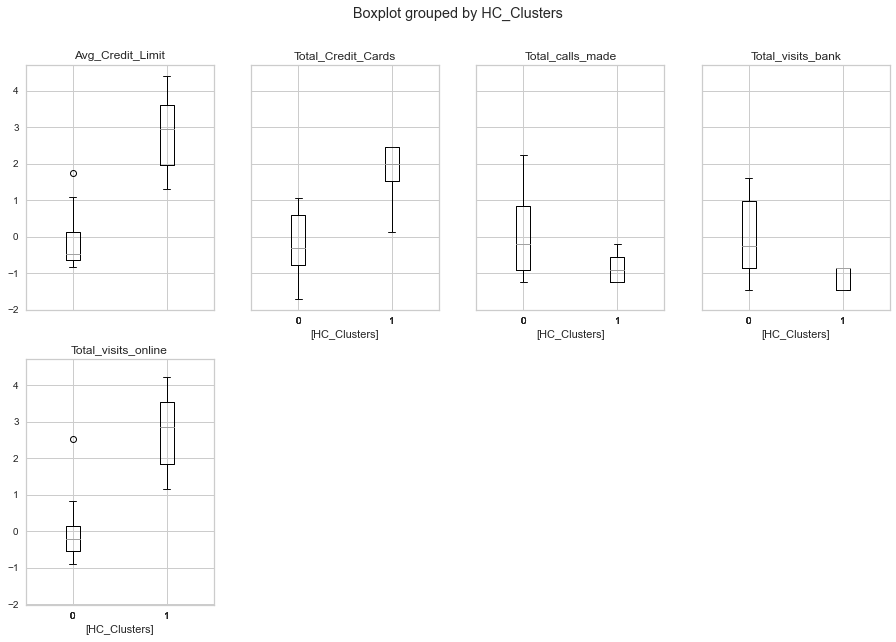

```python
dfHC2Scaled.boxplot(by='HC_Clusters', layout = (2,4),figsize=(15,10))
```

#### Observations

- Some nice variance between groups with 2 clusters
- I predict that 3 clusters will provide even greater variance, since that's what happened in k-means

```python
dfHC3 = df.copy(deep = True)
dfHC3Scaled = dfScaled.copy(deep = True)

HC3 = AgglomerativeClustering(n_clusters=3, affinity="euclidean", linkage="average")
HC3.fit(dfHC3Scaled)

dfHC3Scaled["HC_Clusters"] = HC3.labels_
dfHC3["HC_Clusters"] = HC3.labels_
```

```python
dfHC3Clust = dfHC3.groupby(['HC_Clusters'])
dfHC3Clust.mean()
```

| HC_Clusters | Avg_Credit_Limit | Total_Credit_Cards | Total_visits_bank | Total_visits_online | Total_calls_made |
| --- | --- | --- | --- | --- | --- |
| 0 | 33713.178295 | 5.511628 | 3.485788 | 0.984496 | 2.005168 |
| 1 | 141040.000000 | 8.740000 | 0.600000 | 10.900000 | 1.080000 |
| 2 | 12197.309417 | 2.403587 | 0.928251 | 3.560538 | 6.883408 |

```
array([[<AxesSubplot:title={'center':'Avg_Credit_Limit'}, xlabel='[HC_Clusters]'>,
        <AxesSubplot:title={'center':'Total_Credit_Cards'}, xlabel='[HC_Clusters]'>,
        <AxesSubplot:title={'center':'Total_calls_made'}, xlabel='[HC_Clusters]'>,
        <AxesSubplot:title={'center':'Total_visits_bank'}, xlabel='[HC_Clusters]'>],
       [<AxesSubplot:title={'center':'Total_visits_online'}, xlabel='[HC_Clusters]'>,
        <AxesSubplot:>, <AxesSubplot:>, <AxesSubplot:>]], dtype=object)
```

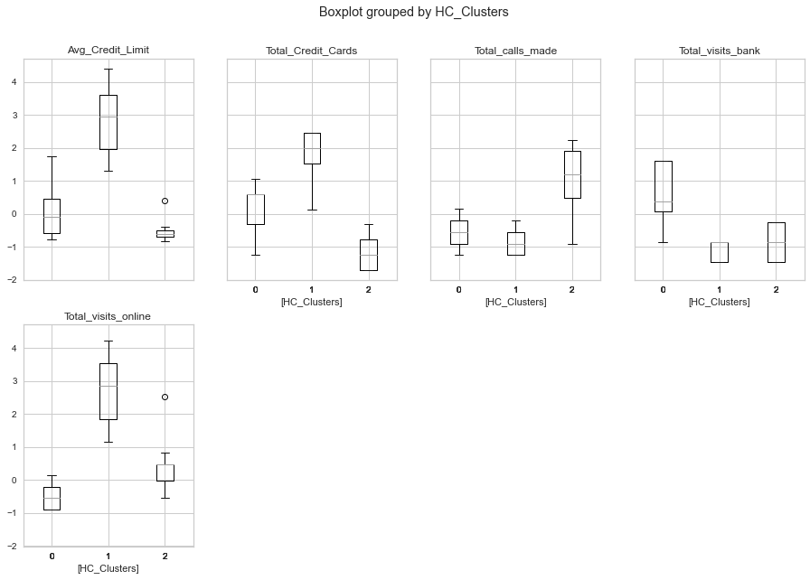

```python
dfHC3Scaled.boxplot(by='HC_Clusters', layout = (2,4),figsize=(15,10))
```

#### Observations

- As predicted, we get great variation across all variables for 3 clusters
- I would consider this to be an improvement over two clusters. In spite of the lower silhouette score, 3 clusters seems to give an ideal amount of variation.

```python
dfHC4 = df.copy(deep = True)
dfHC4Scaled = dfScaled.copy(deep = True)

HC4 = AgglomerativeClustering(n_clusters=4, affinity="euclidean", linkage="average")
HC4.fit(dfHC4Scaled)

dfHC4Scaled["HC_Clusters"] = HC4.labels_
dfHC4["HC_Clusters"] = HC4.labels_
```

```python
dfHC4Clust = dfHC4.groupby(['HC_Clusters'])
dfHC4Clust.mean()
```

| HC_Clusters | Avg_Credit_Limit | Total_Credit_Cards | Total_visits_bank | Total_visits_online | Total_calls_made |
| --- | --- | --- | --- | --- | --- |
| 0 | 12197.309417 | 2.403587 | 0.928251 | 3.560538 | 6.883408 |
| 1 | 141040.000000 | 8.740000 | 0.600000 | 10.900000 | 1.080000 |
| 2 | 33541.450777 | 5.520725 | 3.492228 | 0.984456 | 2.010363 |
| 3 | 100000.000000 | 2.000000 | 1.000000 | 1.000000 | 0.000000 |

```
array([[<AxesSubplot:title={'center':'Avg_Credit_Limit'}, xlabel='[HC_Clusters]'>,
        <AxesSubplot:title={'center':'Total_Credit_Cards'}, xlabel='[HC_Clusters]'>,
        <AxesSubplot:title={'center':'Total_calls_made'}, xlabel='[HC_Clusters]'>,
        <AxesSubplot:title={'center':'Total_visits_bank'}, xlabel='[HC_Clusters]'>],
       [<AxesSubplot:title={'center':'Total_visits_online'}, xlabel='[HC_Clusters]'>,
        <AxesSubplot:>, <AxesSubplot:>, <AxesSubplot:>]], dtype=object)
```

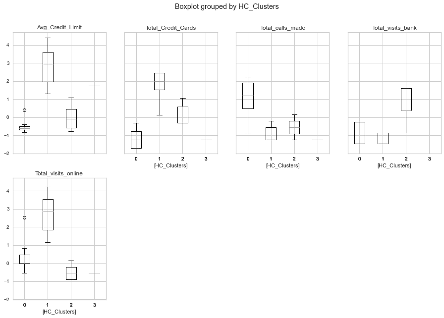

```python
dfHC4Scaled.boxplot(by='HC_Clusters', layout = (2,4),figsize=(15,10))
```

#### Observations

- Group 3 is so small as to be almost non-existent
- Based on this, and the fact that 4 represented a lower silhouette score, 4 is not an ideal number of groups for hierarchical clustering
- Looks like 3 is the best number of groups, both for hierarchical and k-means clustering

### Comparing k-means to hierarchical

- I will compare both results by answering the following questions:
  - Which clustering technique took less time for execution?
  - Which clustering technique gave you more distinct clusters?
  - How do the silhouette scores vary?
  - How many observations are there in the similar clusters of both algorithms?
  - How many clusters are obtained as the appropriate number of clusters from both algorithms?

#### Which clustering technique took less time for execution?

The answer is clearly k-means clustering. The code for hierarchical clustering took a bit longer to run, although not by much. Given the relatively small size of our dataframe, 660 x 660 distance comparisons in hierarchical wasn't that much more computationally expensive than 660 x 2-9 comparisons to centroid in k-means

#### Which clustering technique gave you more distinct clusters?

To answer this, I will re-visit the box plots for my best models.

```python
# K-means clustering with 3 clusters

dfk3Scaled.boxplot(by='Group', layout = (2,4),figsize=(15,10))
```

[output not shown]

```
array([[<AxesSubplot:title={'center':'Avg_Credit_Limit'}, xlabel='[Group]'>,
        <AxesSubplot:title={'center':'Total_Credit_Cards'}, xlabel='[Group]'>,
        <AxesSubplot:title={'center':'Total_calls_made'}, xlabel='[Group]'>,
        <AxesSubplot:title={'center':'Total_visits_bank'}, xlabel='[Group]'>],
       [<AxesSubplot:title={'center':'Total_visits_online'}, xlabel='[Group]'>,
        <AxesSubplot:>, <AxesSubplot:>, <AxesSubplot:>]], dtype=object)
```

```
array([[<AxesSubplot:title={'center':'Avg_Credit_Limit'}, xlabel='[HC_Clusters]'>,
        <AxesSubplot:title={'center':'Total_Credit_Cards'}, xlabel='[HC_Clusters]'>,
        <AxesSubplot:title={'center':'Total_calls_made'}, xlabel='[HC_Clusters]'>,
        <AxesSubplot:title={'center':'Total_visits_bank'}, xlabel='[HC_Clusters]'>],
       [<AxesSubplot:title={'center':'Total_visits_online'}, xlabel='[HC_Clusters]'>,
        <AxesSubplot:>, <AxesSubplot:>, <AxesSubplot:>]], dtype=object)
```

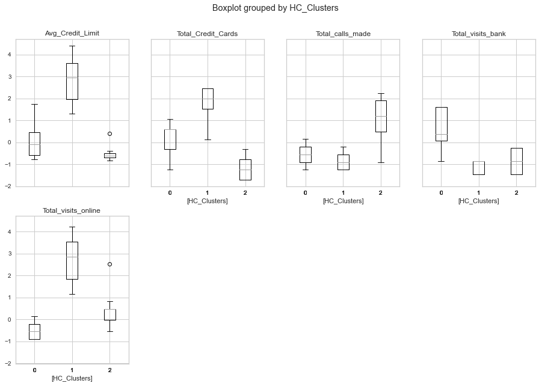

```python
# Hierarchical clustering with 3 clusters, average linkage, and Euclidean distance

dfHC3Scaled.boxplot(by='HC_Clusters', layout = (2,4),figsize=(15,10))
```

#### Observations

Comparing variable by variable:

- Avg_Credit_Limit
  - For the hierarchical clustering, I get very similar clusters in groups 0 and 2
  - The three clusters are distinct in k-means
  - K-Means wins this round
- Total_Credit_Cards
  - Both have quite distinct groups
  - I'll call this one a tie
- Total_calls_made
  - The hierarchical clustering has quite a bit of overlap between groups 0 and 1
  - K-Means has the same issue for groups 1 and 2
  - For this variable, the models tie
- Total_visits_bank
  - Hierarchical has overlap between groups 1 and 2
  - K-means has the same issue for groups 0 and 2
  - This one is yet again a tie
- Total_visits_online
  - Both models have very distinct groups
  - Again, I will call a tie
- CONCLUSION: k-means barely edges hierarchical for this question. This is very close.

#### How do the silhouette scores vary?

Copying from above:

- Hierarchical: For n_clusters = 3, silhouette score is 0.5159224326510256
- K-Means: For n_clusters = 3, silhouette score is 0.5157182558881671
- This is essentially a tie. We have to go to the ten-thousandths place to give the slight edge to Hierarchical.

#### How many observations are there in the similar clusters of both algorithms?

I will use value-counts to measure this

```python
# k-means:

dfk3Scaled.Group.value_counts()
```

```
2    386
1    224
0     50
Name: Group, dtype: int64
```

```python
dfHC3Scaled.HC_Clusters.value_counts()
```

```
0    387
2    223
1     50
Name: HC_Clusters, dtype: int64
```

#### Observations

- Again, this is essentially a tie
- k-means takes a very slight edge for having slightly more homogenous groups, but it is only by a single observation. !!!

#### How many clusters are obtained as the appropriate number of clusters from both algorithms?

- This is obviously a tie - both methods resulted in 3 clusters.

#### Which is best?

- Both methods resulted in VERY similar clusters. Given that k-means was slightly better on a couple of key questions, and especially given the time-save, I choose k-means, with 3 clusters, as my final model.

### Conclusions

```python
dfk3Scaled.boxplot(by='Group', layout = (2,4),figsize=(15,10))
```

[output not shown]

```
array([[<AxesSubplot:title={'center':'Avg_Credit_Limit'}, xlabel='[Group]'>,
        <AxesSubplot:title={'center':'Total_Credit_Cards'}, xlabel='[Group]'>,
        <AxesSubplot:title={'center':'Total_calls_made'}, xlabel='[Group]'>,
        <AxesSubplot:title={'center':'Total_visits_bank'}, xlabel='[Group]'>],
       [<AxesSubplot:title={'center':'Total_visits_online'}, xlabel='[Group]'>,
        <AxesSubplot:>, <AxesSubplot:>, <AxesSubplot:>]], dtype=object)
```

### Ideas for Future Research

- In order to improve customer service, the bank should follow up a certain percentage of customer service interactions with a survey to determine specific areas that need improvement. We should include metrics such as rating the friendliness and knowledgability of the customer service representative, identifying how many contacts were required for the issue to be resolved, how likely the client would be to recommend us to a friend or family member, and overall satisfaction rating. It would be helpful if the answers could be in numeric form, to most easily translate into a regression model to determine the best ways to meet our client needs.